# Uber Data Analysis

##Importing Packages [ggplot2, ggthemes, lubridate, dplyr, tidyr, DT, scales]

```r
library(ggplot2)
library(ggthemes)
library(lubridate)
library(dplyr)
library(tidyr)
library(DT)
library(scales)
```

##Creating vector of colors for the plots

```r
colors = c("#2f2d2d", "#eaeaea", "#05a399", "#7676a7", "#f5e840", "#ab47bc", "#388e3c")
colors
```

```
## [1] "#2f2d2d" "#eaeaea" "#05a399" "#7676a7" "#f5e840" "#ab47bc" "#388e3c"
```

##Current Working Directory

```r
getwd()
```

```
## [1] "C:/Users/py96230n/Desktop/Uberdata"
```

##Reading the data for each month separately

```r
apr <- read.csv("C:/Users/py96230n/Desktop/Uberdata/uber-raw-data-apr14.csv")
may <- read.csv("C:/Users/py96230n/Desktop/Uberdata/uber-raw-data-may14.csv")
june <- read.csv("C:/Users/py96230n/Desktop/Uberdata/uber-raw-data-jun14.csv")
july <- read.csv("C:/Users/py96230n/Desktop/Uberdata/uber-raw-data-jul14.csv")
aug <- read.csv("C:/Users/py96230n/Desktop/Uberdata/uber-raw-data-aug14.csv")
sept <- read.csv("C:/Users/py96230n/Desktop/Uberdata/uber-raw-data-sep14.csv")
```

##Combine the data together #rbind multiple group of rows

```r
data <- rbind(apr, may, june, july, aug, sept)
cat("The dimensions of the data are:", dim(data))
```

```
## The dimensions of the data are: 4534327 4
```

```r
head(data)
```

```
##          Date.Time     Lat      Lon   Base
## 1 4/1/2014 0:11:00 40.7690 -73.9549 B02512
## 2 4/1/2014 0:17:00 40.7267 -74.0345 B02512
## 3 4/1/2014 0:21:00 40.7316 -73.9873 B02512
## 4 4/1/2014 0:28:00 40.7588 -73.9776 B02512
## 5 4/1/2014 0:33:00 40.7594 -73.9722 B02512
## 6 4/1/2014 0:33:00 40.7383 -74.0403 B02512
```

##Readable format for the DateTime

```r
data$Date.Time <- as.POSIXct(data$Date.Time, format="%m/%d/%Y %H:%M:%S")
data$Time <- format(as.POSIXct(data$Date.Time, format = "%m/%d/%Y %H:%M:%S"), format="%H:%M:%S")
data$Date.Time <- ymd_hms(data$Date.Time)
head(data)
```

```
##             Date.Time     Lat      Lon   Base     Time
## 1 2014-04-01 00:11:00 40.7690 -73.9549 B02512 00:11:00
## 2 2014-04-01 00:17:00 40.7267 -74.0345 B02512 00:17:00
## 3 2014-04-01 00:21:00 40.7316 -73.9873 B02512 00:21:00
## 4 2014-04-01 00:28:00 40.7588 -73.9776 B02512 00:28:00
## 5 2014-04-01 00:33:00 40.7594 -73.9722 B02512 00:33:00
## 6 2014-04-01 00:33:00 40.7383 -74.0403 B02512 00:33:00
```

#Create individual columns for month, day and year

```r
data$day <- factor(day(data$Date.Time))
data$month <- factor(month(data$Date.Time, label=TRUE))
data$year <- factor(year(data$Date.Time))
data$dayofweek <- factor(wday(data$Date.Time, label=TRUE))
head(data)
```

```
##             Date.Time     Lat      Lon   Base     Time day month year dayofweek
## 1 2014-04-01 00:11:00 40.7690 -73.9549 B02512 00:11:00   1   Apr 2014       Tue
## 2 2014-04-01 00:17:00 40.7267 -74.0345 B02512 00:17:00   1   Apr 2014       Tue
## 3 2014-04-01 00:21:00 40.7316 -73.9873 B02512 00:21:00   1   Apr 2014       Tue
## 4 2014-04-01 00:28:00 40.7588 -73.9776 B02512 00:28:00   1   Apr 2014       Tue
## 5 2014-04-01 00:33:00 40.7594 -73.9722 B02512 00:33:00   1   Apr 2014       Tue
## 6 2014-04-01 00:33:00 40.7383 -74.0403 B02512 00:33:00   1   Apr 2014       Tue
```

#Adding Time variables

```r
data$second = factor(second(hms(data$Time)))
data$minute = factor(minute(hms(data$Time)))
data$hour = factor(hour(hms(data$Time)))
head(data)
```

```
##             Date.Time     Lat      Lon   Base     Time day month year dayofweek
## 1 2014-04-01 00:11:00 40.7690 -73.9549 B02512 00:11:00   1   Apr 2014       Tue
## 2 2014-04-01 00:17:00 40.7267 -74.0345 B02512 00:17:00   1   Apr 2014       Tue
## 3 2014-04-01 00:21:00 40.7316 -73.9873 B02512 00:21:00   1   Apr 2014       Tue
## 4 2014-04-01 00:28:00 40.7588 -73.9776 B02512 00:28:00   1   Apr 2014       Tue
## 5 2014-04-01 00:33:00 40.7594 -73.9722 B02512 00:33:00   1   Apr 2014       Tue
## 6 2014-04-01 00:33:00 40.7383 -74.0403 B02512 00:33:00   1   Apr 2014       Tue
##   second minute hour
## 1      0     11    0
## 2      0     17    0
## 3      0     21    0
## 4      0     28    0
## 5      0     33    0
## 6      0     33    0
```

##Data Visualisation

#Plotting the trips by hours in a day

```r
hourly_data <- data %>%
  group_by(hour) %>%
  dplyr::summarize(Total = n())
hourly_data
```

```
## # A tibble: 24 × 2
##    hour   Total
##    <fct>  <int>
##  1 0     103836
##  2 1      67227
##  3 2      45865
##  4 3      48287
##  5 4      55230
##  6 5      83939
##  7 6     143213
##  8 7     193094
##  9 8     190504
## 10 9     159967
## # ℹ 14 more rows
```

```r
datatable(hourly_data)
```

|  | hour | Total |
| --- | --- | --- |
| 1 | 0 | 103836 |
| 2 | 1 | 67227 |
| 3 | 2 | 45865 |
| 4 | 3 | 48287 |
| 5 | 4 | 55230 |
| 6 | 5 | 83939 |
| 7 | 6 | 143213 |
| 8 | 7 | 193094 |
| 9 | 8 | 190504 |
| 10 | 9 | 159967 |

[output cut: 14 more lines]

#Plot the data by hour

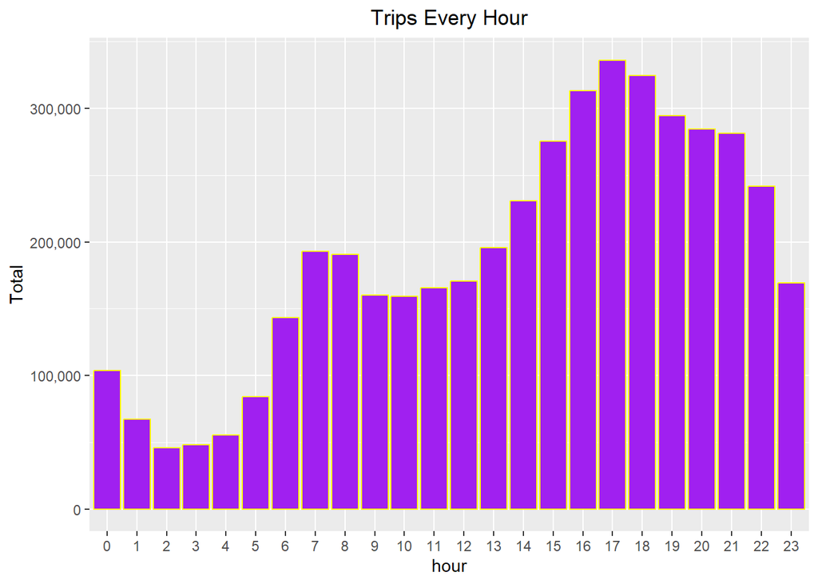

```r
ggplot(hourly_data, aes(hour, Total)) +
  geom_bar(stat="identity",
           fill="purple",
           color="yellow") +
  ggtitle("Trips Every Hour") +
  theme(legend.position = "none",
        plot.title = element_text(hjust = 0.5),
        plot.subtitle = element_text(hjust = 0.5)) +
  scale_y_continuous(labels=comma)
```

##Plotting trips by hour and month #Aggregate the data by month and hour

```r
month_hour_data <- data %>% group_by(month, hour) %>%  dplyr::summarize(Total = n())
```

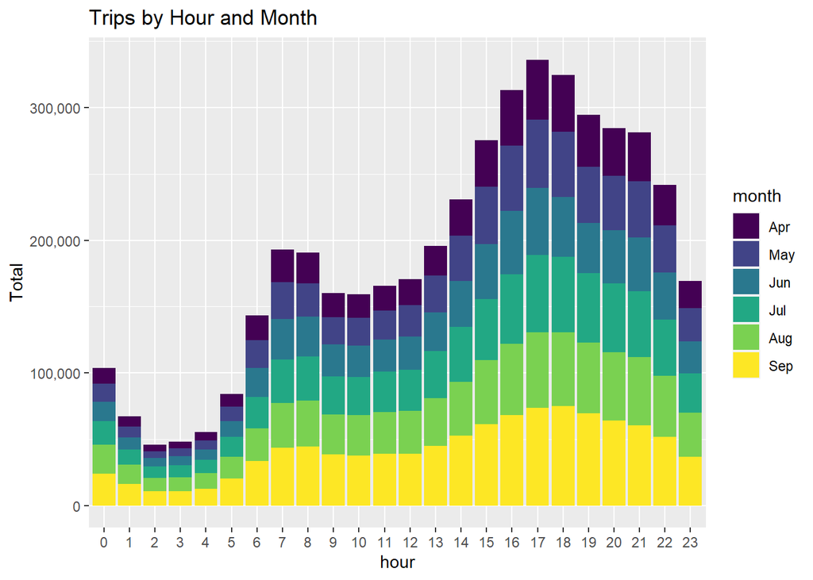

```r
ggplot(month_hour_data, aes(hour, Total, fill=month)) +
  geom_bar(stat = "identity") +
  ggtitle("Trips by Hour and Month") +
  scale_y_continuous(labels = comma)
```

#Plotting data by trips during every day of the month

```r
day_data <- data %>% group_by(day) %>% dplyr::summarize(Trips = n())
day_data
```

```
## # A tibble: 31 × 2
##    day    Trips
##    <fct>  <int>
##  1 1     127430
##  2 2     143201
##  3 3     142983
##  4 4     140923
##  5 5     147054
##  6 6     139886
##  7 7     143503
##  8 8     145984
##  9 9     155135
## 10 10    152500
## # ℹ 21 more rows
```

#Data for the day

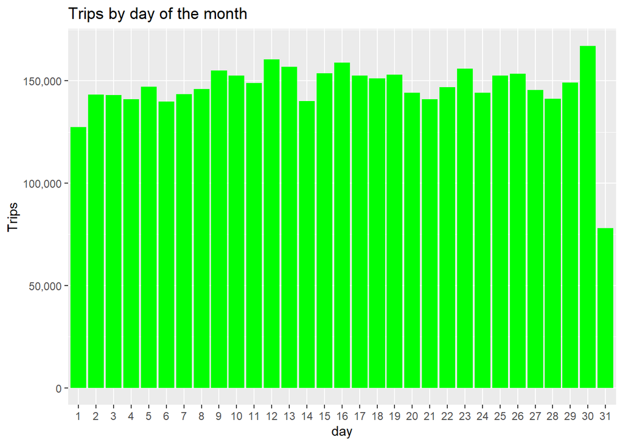

```r
ggplot(day_data, aes(day, Trips)) +
  geom_bar(stat = "identity", fill = "green") +
  ggtitle("Trips by day of the month") +
  theme(legend.position = "none") +
  scale_y_continuous(labels = comma)
```

##Collect data by day of the week and month

```r
day_month_data <- data %>% group_by(dayofweek, month) %>% dplyr::summarize(Trips = n())
day_month_data
```

```
## # A tibble: 42 × 3
## # Groups:   dayofweek [7]
##    dayofweek month  Trips
##    <ord>     <ord>  <int>
##  1 Sun       Apr    51251
##  2 Sun       May    56168
##  3 Sun       Jun    79656
##  4 Sun       Jul    76327
##  5 Sun       Aug   110246
##  6 Sun       Sep   116532
##  7 Mon       Apr    60861
##  8 Mon       May    63846
##  9 Mon       Jun    94655
## 10 Mon       Jul    93189
## # ℹ 32 more rows
```

#Plot the Collect data by day of the week and month

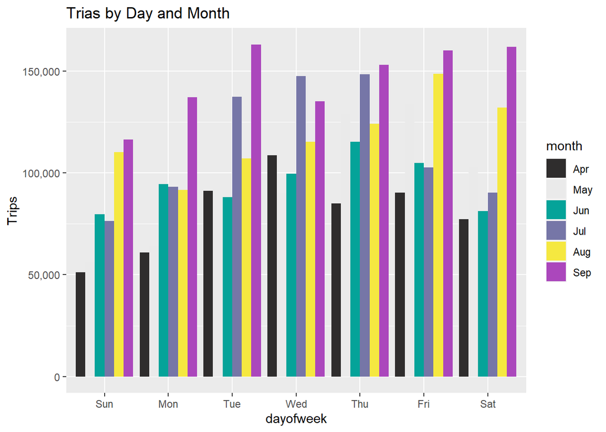

```r
ggplot(day_month_data, aes(dayofweek, Trips, fill = month)) +
  geom_bar(stat = "identity", aes(fill = month), position = "dodge") +
  ggtitle("Trias by Day and Month") +
  scale_y_continuous(labels = comma) +
  scale_fill_manual(values = colors)
```

#Number of Trips place during months in a year

```r
month_data <- data %>% group_by(month) %>% dplyr::summarize(Total = n())
month_data
```

```
## # A tibble: 6 × 2
##   month   Total
##   <ord>   <int>
## 1 Apr    564516
## 2 May    652435
## 3 Jun    663844
## 4 Jul    796121
## 5 Aug    829275
## 6 Sep   1028136
```

#Plot the Number of Trips place during months in a year

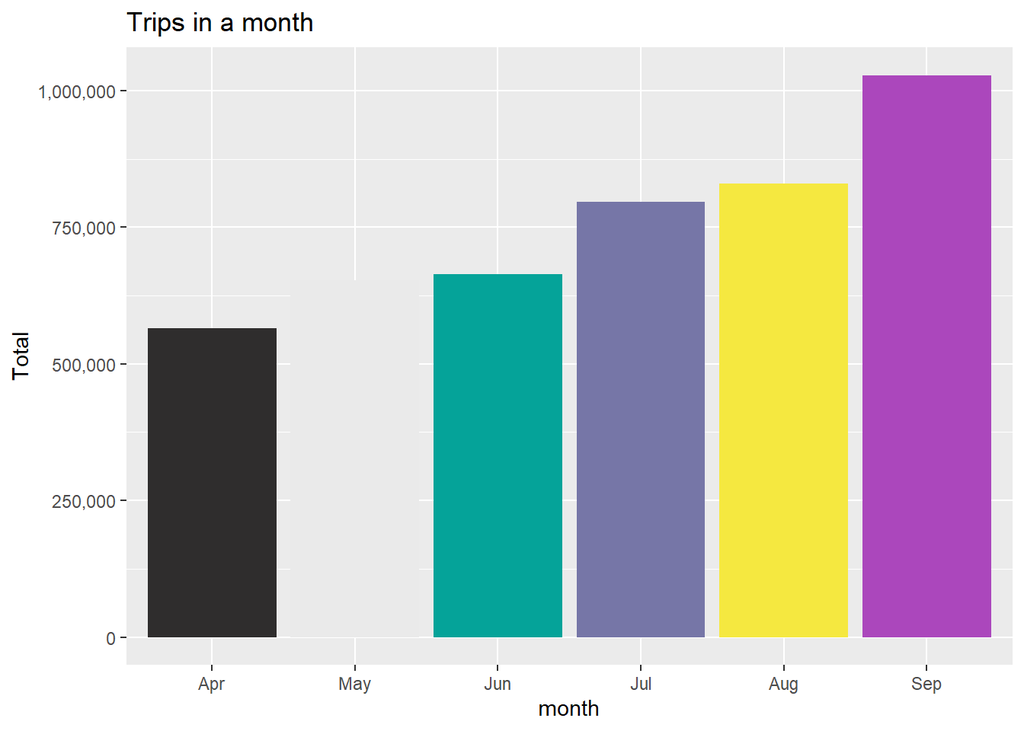

```r
ggplot(month_data, aes(month, Total, fill = month)) +
  geom_bar(stat = "Identity") +
  ggtitle("Trips in a month") +
  theme(legend.position = "none") +
  scale_y_continuous(labels = comma) +
  scale_fill_manual(values = colors)
```

##Heatmap visualization of day, hour and month #Heatmap by Hour and Day

```r
day_hour_data <- data %>% group_by(day, hour) %>% dplyr::summarize(Total = n())
```

[output not shown]

```r
datatable(day_hour_data)
```

|  | day | hour | Total |
| --- | --- | --- | --- |
| 1 | 1 | 0 | 3247 |
| 2 | 1 | 1 | 1982 |
| 3 | 1 | 2 | 1284 |
| 4 | 1 | 3 | 1331 |
| 5 | 1 | 4 | 1458 |
| 6 | 1 | 5 | 2171 |
| 7 | 1 | 6 | 3717 |
| 8 | 1 | 7 | 5470 |
| 9 | 1 | 8 | 5376 |
| 10 | 1 | 9 | 4688 |

[output cut: 734 more lines]

##Heatmap by Hour and Day

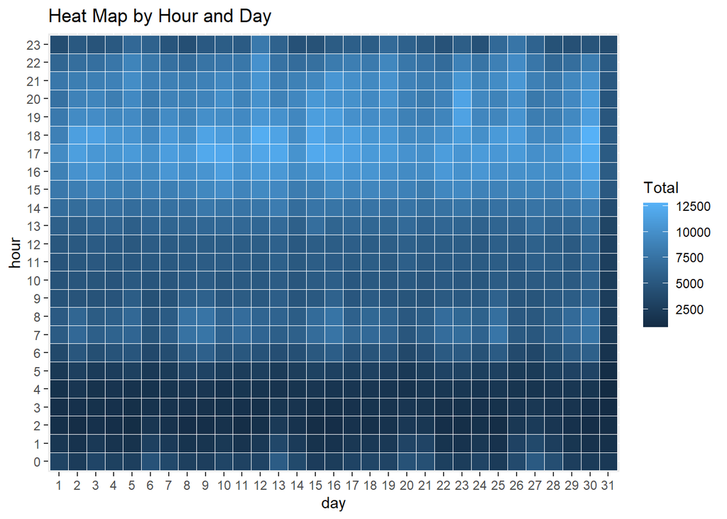

```r
ggplot(day_hour_data, aes(day, hour, fill = Total)) +
  geom_tile(color = "white") +
  ggtitle("Heat Map by Hour and Day")
```

##Heatmap by Day and Month

```r
month_day_data <- data %>% group_by(month, day) %>% dplyr::summarize(Trips = n())
month_day_data
```

```
## # A tibble: 183 × 3
## # Groups:   month [6]
##    month day   Trips
##    <ord> <fct> <int>
##  1 Apr   1     14546
##  2 Apr   2     17474
##  3 Apr   3     20701
##  4 Apr   4     26714
##  5 Apr   5     19521
##  6 Apr   6     13445
##  7 Apr   7     19550
##  8 Apr   8     16188
##  9 Apr   9     16843
## 10 Apr   10    20041
## # ℹ 173 more rows
```

##Heatmap by Collecting data by month and day

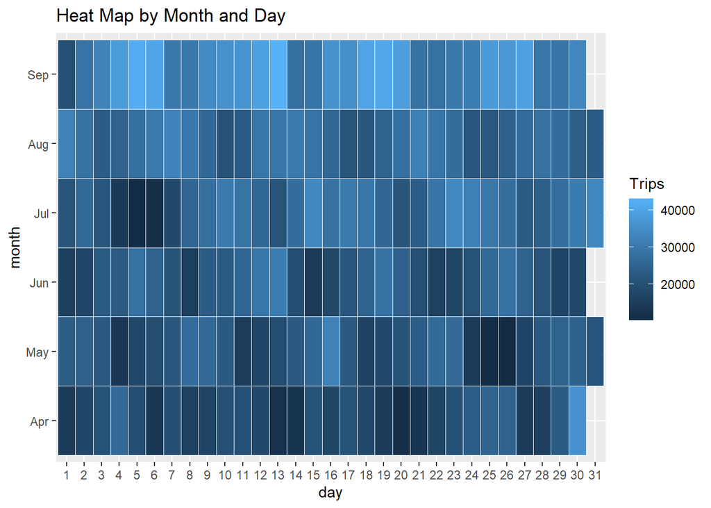

```r
ggplot(month_day_data, aes(day, month, fill = Trips)) +
  geom_tile(color = "white") +
  ggtitle("Heat Map by Month and Day")
```

##Heatmap by day of the week and month

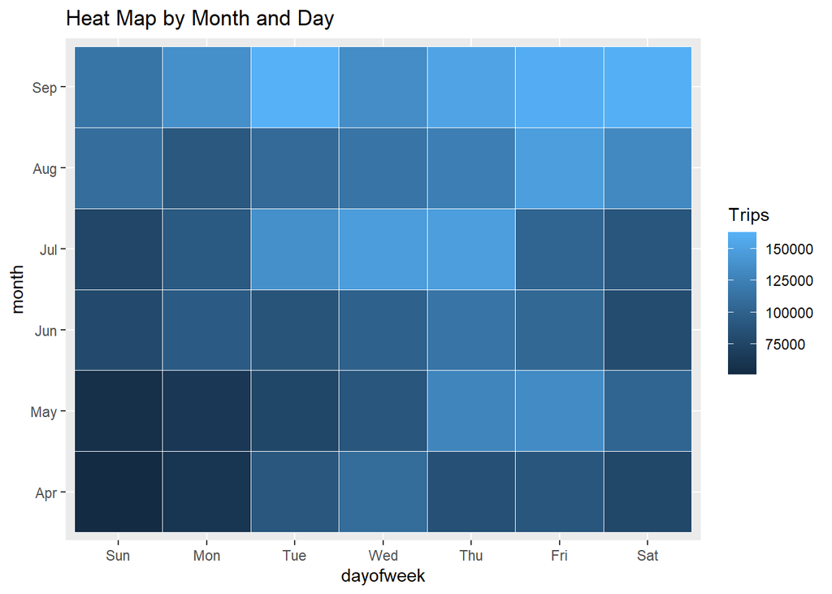

```r
ggplot(day_month_data, aes(dayofweek, month, fill = Trips)) +
  geom_tile(color = "white") +
  ggtitle("Heat Map by Month and Day")
```

#Creating a map visualization of rides in NYC #Set Map Constants

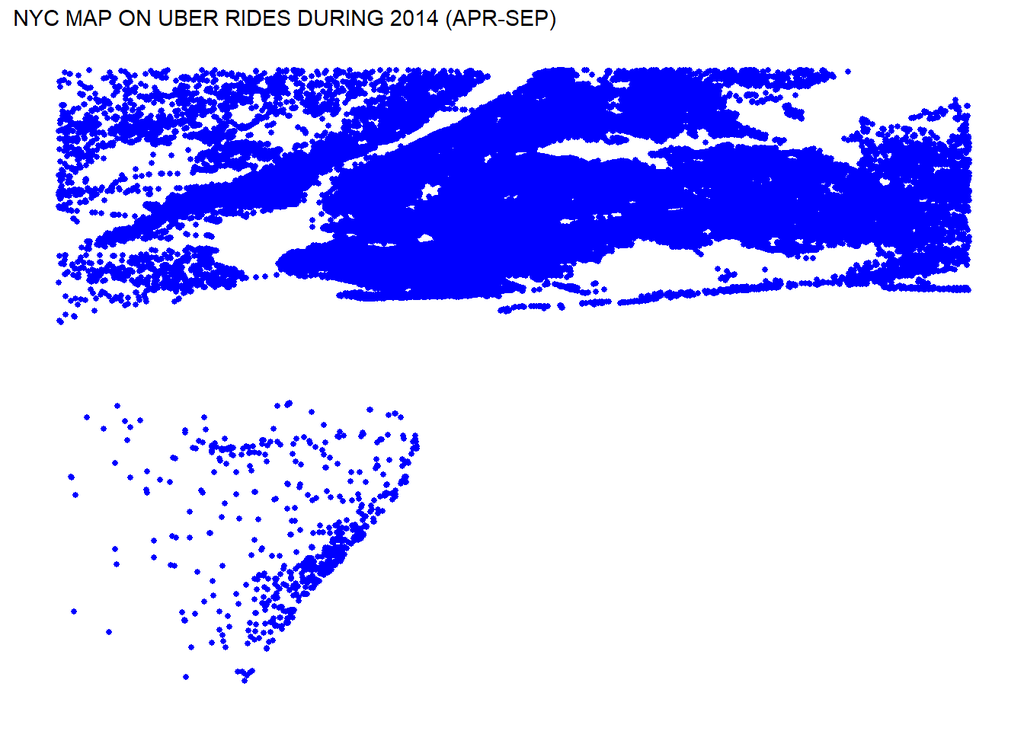

```r
min_lat <- 40
max_lat <- 40.91
min_long <- -74.15
max_long <- -73.7004

ggplot(data, aes(x=Lon, y=Lat)) +
  geom_point(size=1, color = "blue") +
  scale_x_continuous(limits=c(min_long, max_long)) +
  scale_y_continuous(limits=c(min_lat, max_lat)) +
  theme_map() +
   ggtitle("NYC MAP ON UBER RIDES DURING 2014 (APR-SEP)")
```

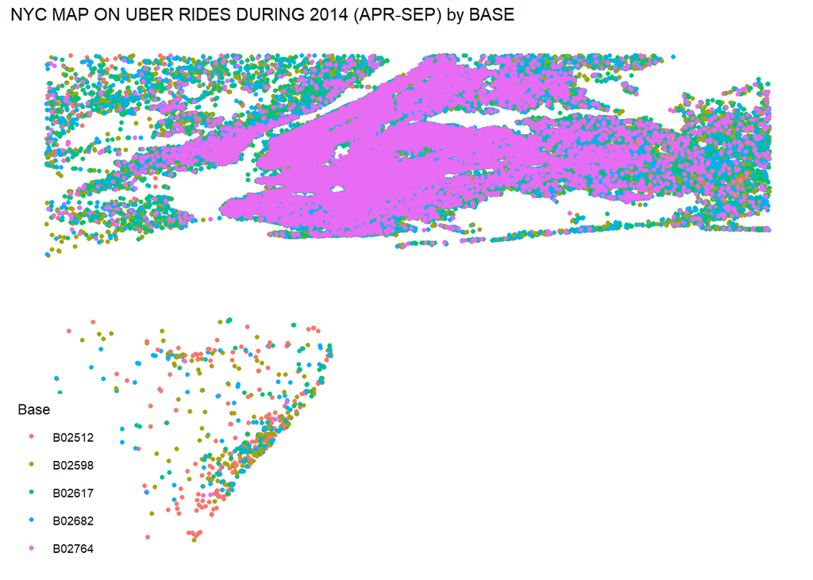

```r
ggplot(data, aes(x=Lon, y=Lat, color = Base)) +
  geom_point(size=1) +
  scale_x_continuous(limits=c(min_long, max_long)) +
  scale_y_continuous(limits=c(min_lat, max_lat)) +
  theme_map() +
  ggtitle("NYC MAP ON UBER RIDES DURING 2014 (APR-SEP) by BASE")
```